# The Politics of Corruption

Lecture 13: Technology Against Corruption? Algorithms, Satellites, and the Limits of Detection

Bogdan G. Popescu

bgpopescu@tec.mx

Tecnológico de Monterrey

## Today

**Can technology expose or prevent corruption?** Three cases, three questions:

1. **Mexico.** Can an algorithm find the suspicious contracts a small audit team would otherwise miss?
2. **India.** What happens when the people being measured work out exactly how the measuring is done?
3. **Autocracies.** Can data a government does not control catch it exaggerating its own success?

One claim runs through all three:

> Technology can make wrongdoing much easier to **detect**. Whether it makes wrongdoing *rarer* depends on who has the **incentive** and the **power** to act.

# I. What makes an anticorruption innovation work?

Image: server room, BalticServers.com, CC BY-SA 3.0, via Wikimedia Commons.

## What must an innovation change?

Imagine a government introduces an AI system that flags suspicious public contracts. **Will corruption actually decline?**

To answer this, we first need to understand what creates opportunities for corruption.

> **more monopoly + more discretion − less accountability = more corruption risk**

Klitgaard writes this as **C = M + D − A** — the shorthand from session 3.

## Four questions to ask of any innovation

1. **Does it address a cause of corruption?**
   - More competition, less discretion, more accountability.
2. **Can anyone act on what it reveals?**
   - A losing firm challenges the award — or nobody bothers, because everyone expects corruption.
3. **Can it be gamed, or turned on people?**
   - Officials hide. Governments point the tool at their opponents.
4. **Does corruption actually fall?**
   - Fewer rigged contracts, not more alerts.

## Three things can happen next

```
%%{init: {"theme":"base","htmlLabels":false,"flowchart":{"useMaxWidth":true,"htmlLabels":false,"wrappingWidth":420,"nodeSpacing":30,"rankSpacing":95,"curve":"basis"},"themeVariables":{"fontSize":"22px","fontFamily":"Arial, Helvetica, sans-serif","lineColor":"#334155","primaryColor":"#eef2f5","primar…
flowchart LR
  T["NEW INFORMATION<br/>a portal, an algorithm,<br/>a satellite"]
  A["SOMEONE ACTS<br/>Wrongdoing gets<br/>harder or riskier"]
  B["NOBODY CAN ACT<br/>A better record,<br/>the same world"]
  C["THE WATCHED ADAPT<br/>The number improves,<br/>the problem does not"]
  T --> A
  T --> B
  T --> C
  classDef tool fill:#4a7c6f,stroke:#2f5349,stroke-width:2px,color:#ffffff;
  classDef good fill:#e3eee9,stroke:#4a7c6f,stroke-width:2.5px,color:#1e293b;
  classDef bad fill:#f6e7e1,stroke:#b44527,stroke-width:2.5px,color:#1e293b;
  class T tool; class A good; class B,C bad;
```

**Mexico aims at the first branch; Punjab landed in the third.** The middle one looks fine on paper.

Framework adapted from Adam and Fazekas (2021).

# II. Machine learning in Mexico

**Questions 2 and 4:** can anyone act on what the data reveals — and does better detection actually reduce corruption?

## You are the auditor. Where do you start?

- The government signs **thousands of contracts** a year. Roads, computers, medicines, school meals.
- A few of them are corrupt. An official quietly favours one company, and takes something in return.
- **Your job:** find those contracts.
- **Your problem:** there are millions of them, and your team is small.

So: **which ones do you open first?**

## First answer: look for warning signs

Investigators have always used **red flags** — features of a contract that suggest something went wrong.

1. **Only one company bids.** Perhaps nobody else was told. Perhaps nobody else was welcome.
2. **The contract is never publicly advertised.** Rival firms never learn the opportunity exists.
3. **Bidders get very little time to prepare.** Only a firm warned in advance could have been ready.
4. **The price is out of line with the market.** The figures look constructed rather than costed.

A red flag is a **reason to look**, not proof of a crime.

Source: Fazekas, Tóth and King (2016); indicator list as summarised in Medina-Hernández et al. (2026).

## Red flags fail in both directions

1. **An honest contract can look suspicious.** One bidder — because only one firm makes the thing.
2. **A corrupt contract can look perfectly normal.** Three bidders — who agreed in advance which of them would win.
3. **And the file often arrives too late to matter.** Publishing the details *before* the award goes with less single bidding. Publishing them afterwards does not.

**The idea:** could a machine read all of them — and catch patterns the simple rules miss?

Timing result: Bauhr, Czibik, de Fine Licht and Fazekas (2020), across 3.5 million European contracts. That is question 2: information only bites if someone can still act on it.

## How do we teach a machine to spot a suspicious contract?

Start with one company. The Mexican government buys computers from **Company A**.

1. **A government database records the purchase.** CompraNet says Company A won the contract — from which agency, for how much.
2. **A separate list records sanctions.** Mexican authorities have already penalised Company A for misconduct.
3. **Put the two together.** A public contract went to a company the state has itself sanctioned.

That makes the contract **worth opening**. It does not make it corrupt.

Illustrative example. The sanction lists come from the tax authority (SAT) and the public administration ministry (SFP) — both independent of the buyers. Source: Medina-Hernández, Kertész and Fazekas (2026).

## But there is a problem

Now do that for **2.3 million contracts**.

1. **1,690 sanctioned companies turn up in the contract records.** Their contracts show us what risk looks like.
2. **And every other company?** Some are honest. Others were simply never caught.
3. **So we cannot sort contracts into “corrupt” and “honest”.** We have sanction-linked contracts, and contracts of unknown status — nothing certified clean.

**The fix: positive–unlabelled learning.** The algorithm learns what sanction-linked suppliers look like **without assuming everyone else is honest**.

Source: Medina-Hernández, Kertész and Fazekas (2026). 12,373 companies sit on the two sanction lists; 1,690 of them won federal contracts, 2011–2022. Sanctions attach to companies, not to individual contracts.

## What if the contract looks perfectly normal?

You are investigating one contract. Agency B buys computers from Supplier 2.

1. **Nothing looks suspicious.** Open tender, three bidders, price in line with the market. No red flag fires — which is not the same as nothing being wrong.
2. **Now look at the other agencies.** Agency C buys from Suppliers 2, 3 and 4 as well. The same small group keeps winning.
3. **Is that corruption?** Not necessarily — they may simply be the serious firms in this market. But it is a question no single contract could have raised.

**The move:** stop reading contracts one at a time. Look at **who buys from whom**, across the whole market.

## Why network position beats a red flag

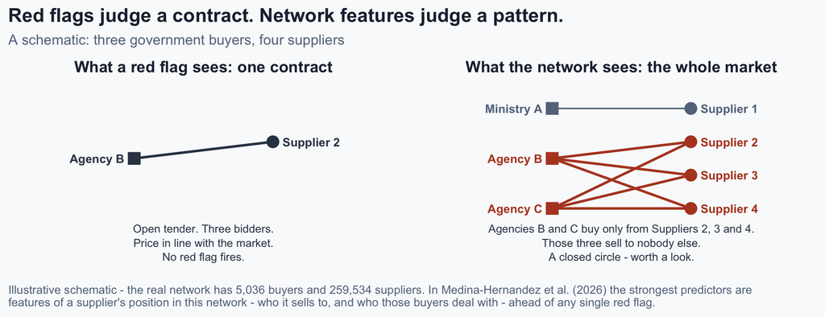

- **Left:** one contract. Nothing stands out.
- **Right:** the same three suppliers, across two agencies — a pattern no single contract could show.
- A network pattern is **a clue, not proof**. The model weighs it alongside the old red flags.

## Does the model actually help?

The researchers ranked all **2.3 million** contracts, most suspicious first. Your audit team has time to open **100**. **Guess both numbers before the next slide.**

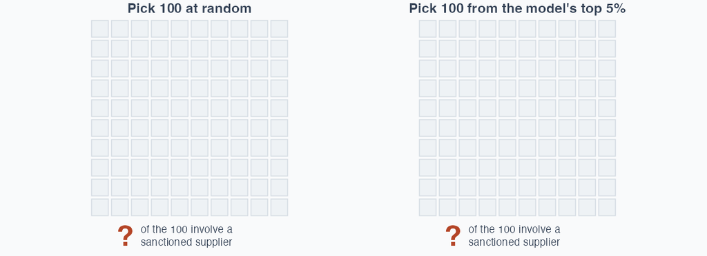

## 100 audits, two ways to choose

[figure not shown]

Source: Medina-Hernández, Kertész and Fazekas (2026): 20% robust precision in the top 5%, about six times random guessing. Measured against sanction-linked contracts in historical data, not a real audit. On a different measure — average lift across the whole ranking — the red-flag index does worse than random.

## So can a machine stop corruption?

1. **What it can do.** Tell a small audit team which contracts to open first — six times better than chance at the top of the list.
2. **What it cannot do.** Prove that any contract is corrupt. Or guarantee that corruption falls.
3. **And one deeper problem.** It learned from past sanctions, and sanctions follow audits. Open tenders get audited more than direct awards. So the model partly learns *where investigators already look* — and inherits their blind spots.

> A detector trained on past enforcement inherits the blind spots of past enforcement.

Source: Medina-Hernández et al. (2026), discussion of label bias by procedure type. The score is a hypothesis about whom to investigate, never a finding.

## So what?

**Mexico showed the promise.** A machine can tell investigators where to look. Someone still has to look, and act.

What happens when the people being measured know exactly **how** they are being watched?

Can they change their behaviour to avoid being caught — without changing what they actually do?

**Next: India.**

# III. When the measure becomes the target

**Question 3:** can the measure be gamed?

Image: smoke over northwestern India, NASA Earth Observatory (VIIRS), 2024, public domain.

## Where Punjab is

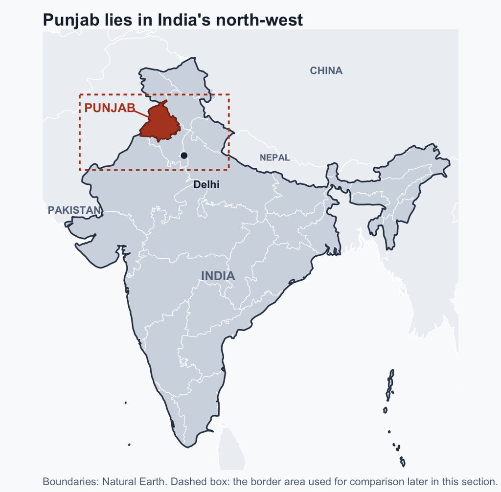

- A farming state on the **Pakistan border** — about 1.5% of India’s land
- Two crops a year: **rice in summer, wheat in winter**. The leftover rice straw is called **stubble**
- Its fields sit **200–300 km upwind of Delhi** and send most of the farm smoke that reaches the capital each winter

## Why they burn, and why nobody stopped them

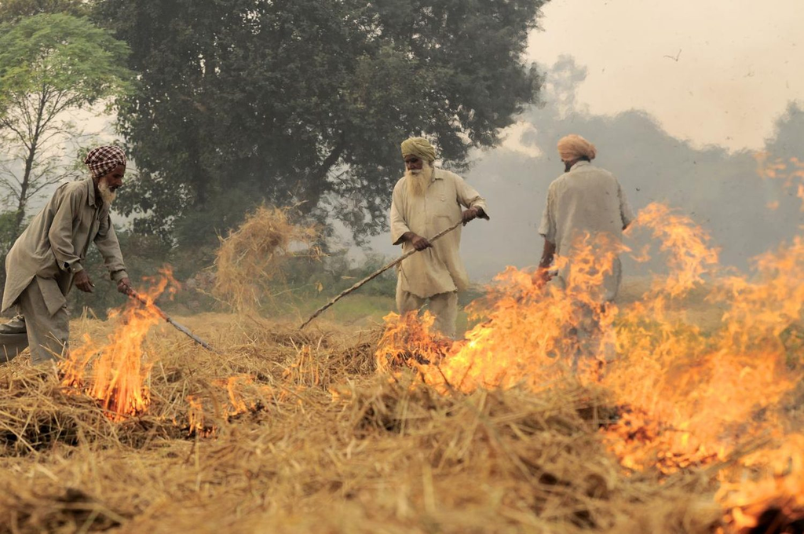

- Rice is cut in October; wheat must be sown **within weeks**
- Burning clears a field in a day — machinery takes longer and costs more
- India’s National Green Tribunal banned it in **2015**
- The ban went unenforced: Punjab’s farmers are politically powerful

**The problem:** how do you stop hundreds of thousands of farmers doing something fast, cheap, and already illegal?

Photo: Neil Palmer (CIAT), 2011, CC BY-SA 2.0, via Wikimedia Commons. Source: Dasgupta (2026).

## 2022: the fires get a target

```
%%{init: {"theme":"base","htmlLabels":false,"flowchart":{"useMaxWidth":true,"htmlLabels":false,"wrappingWidth":400,"nodeSpacing":95,"rankSpacing":55,"curve":"basis"},"themeVariables":{"fontSize":"20px","fontFamily":"Arial, Helvetica, sans-serif","lineColor":"#334155","primaryColor":"#eef2f5","primar…
flowchart LR
  N["SATELLITES SPOT THE FIRES<br/>Each day's burning fields,<br/>texted out as map points"]
  V["A VILLAGE OFFICER MUST ACT<br/>Go to the field, photograph it,<br/>record a fine"]
  D["A DISTRICT HEAD IS SCORED<br/>Target: fires detected<br/>down 50%"]
  N --> V --> D
  classDef tool fill:#4a7c6f,stroke:#2f5349,stroke-width:2px,color:#ffffff;
  classDef mid fill:#eef2f5,stroke:#334155,stroke-width:1.5px,color:#1e293b;
  classDef gate fill:#b7943a,stroke:#7d6222,stroke-width:2.5px,color:#1e293b;
  class N tool; class V mid; class D gate;
```

One party now governed both Delhi and Punjab — it owned the smoke and the air the smoke ruined. It declared zero tolerance and turned the satellite count into a **performance target**.

**The expectation:** if a fire can be seen from space, burning stops.

Source: Dasgupta (2026). Districts were told to cut detected fires by 50% against their 2022 baseline. Roughly 8,000 village officers; officers faced suspension for repeated fires without enforcement.

## The fires disappeared. Why didn’t the smoke?

By 2024 Punjab recorded **10,909** fires — about 70% below 2023, the lowest in the satellite record. The government celebrated.

**PM2.5 is very fine air pollution** — any particle under 2.5 thousandths of a millimetre across, smoke and soot among them. Small enough to slip past your nose and throat, into the lungs, and on into the blood.

The WHO’s guideline for a *single day* is **15**. Delhi’s *monthly* average tops **200**.

## The fires disappeared. Why didn’t the smoke?

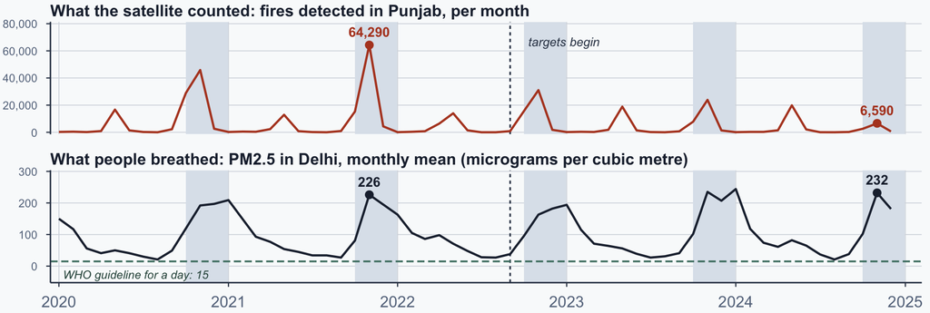

**Turn to your neighbour:** the fires fell and the smoke did not. What could explain that?

Shaded: the Oct–Dec season the policy targeted; the smaller spring peaks fall outside it. Vertical dashed: targets begin, Sept 2022. Green dashed: WHO guideline. Redrawn from Dasgupta (2026), Fig. 2 — VIIRS and Delhi US-embassy PM2.5, read off the figure, so close but not exact. Delhi’s air has other sources too.

## Satellites keep office hours

Imagine a speed camera that only switches on around lunchtime.

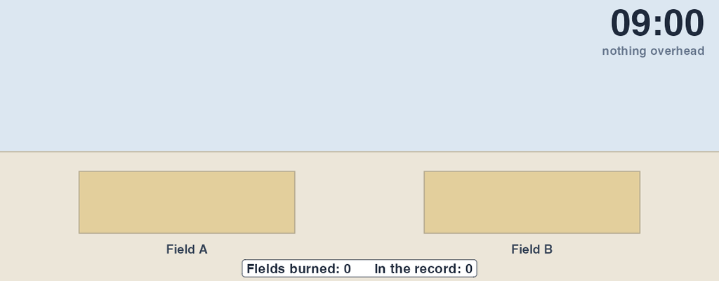

- A burn takes **two or three hours**. Light it late in the afternoon and it is cold ash before anything passes overhead again.
- So the target was **detected** fires. Not fires.

Schematic. Several satellites cross in the 10:30–13:30 window; the animation sends one across it. Source: Dasgupta (2026).

## One field, five days apart

8 November 2021 — burning Punjab, 31.1°N 74.6°E

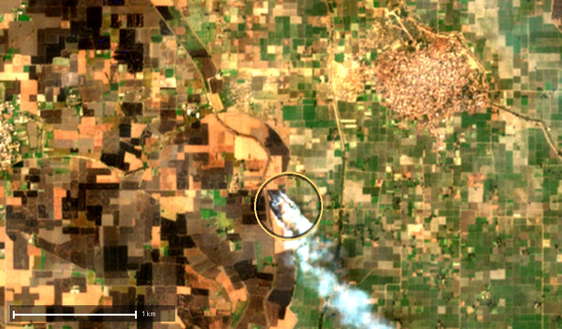

White smoke pouring off the ringed field.

13 November 2021 — burned Same ring, same field

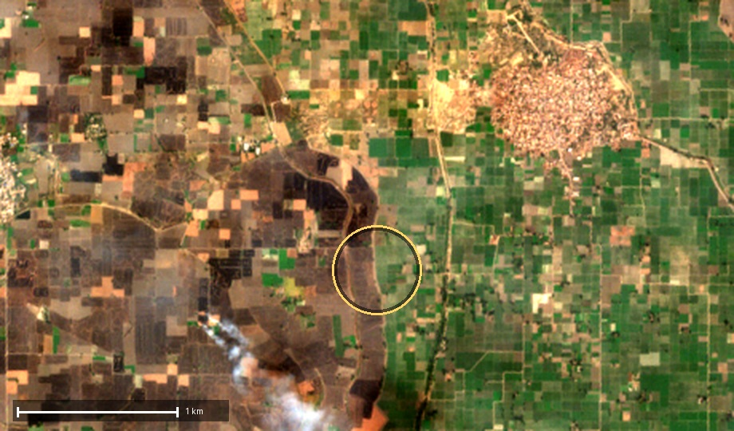

No fire here now. The ground is grey-black.

**The flame lasts hours. The mark lasts weeks.** A fire counts only if something was overhead while it burned — the scar is there whenever you look. That is how Dasgupta finds the missed fires.

True colour, as the eye would see it from orbit. Sentinel-2, 10 m per pixel, 4.6 km across. Contains modified Copernicus Sentinel data (2021) — before the targets began.

## Why might officials help farmers hide?

Overpass times are published. A farmer with a few hectares does not look them up.

1. **Enforcing meant confronting neighbours.** The village fire officer lives in the village. Farmers gathered to threaten them.
2. **The district head needed the count to fall.** In the Indian civil service, postings and promotions turn on looking effective.
3. **So there was an easier way out.** Tell the farmers when the satellite passes. The count falls; nobody is confronted.

**Nobody has caught an official doing this.** The evidence shows the incentive, and a pattern of hidden fires that fits it.

And notice who was being measured: not the farmers, the **officials**.

Source: Dasgupta (2026), drawing on interviews with Punjab officials; the paper treats district head and village officers as one decision-making unit. A plausible mechanism consistent with the evidence, not a directly observed conspiracy.

## Compared with what?

Suppose fires fell everywhere that year because the weather was different. How would we know Punjab’s targets did anything?

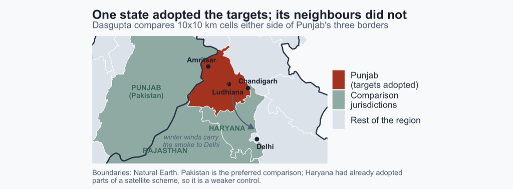

**Same weather, same soils, same crops — different policy.** Did fires fall in Punjab more than they fell just across the border?

## For every 100 fires that vanished, about 22 really stopped

The researchers compared what the satellites detected with what the burn scars say actually happened.

**Imagine 100 fires disappearing from Punjab’s official record.**

Where the official decline actually went

| What became of those 100 fires | About |
| --- | --- |
| **Really stopped** — the field was not burned | **22** |
| **Still burned** — just not while anything was watching | **78** |

**So burning really did fall — nothing like as far as the record claimed.**

Dasgupta (2026), Tables 1–2: the cross-border gap in detected fires narrowed by about 100 fires per 100 sq km per season, of which about 22 were a real fall. Two estimated effects scaled to a round 100 — not a tally of individual fires.

## What went wrong?

1. **What did the government want?** Fewer fields burned.
2. **What did it measure?** Fires a satellite happened to be overhead to see.
3. **What happened to the burning?** It moved out of the satellite’s view.
4. **What did the number do?** It fell by 100. The burning fell by about 22.

> **Goodhart’s law.** When a measure becomes a target, it stops being a good measure — because now someone has a reason to move the number rather than the thing.

**The anticorruption version:** detecting fewer violations is not the same as there being fewer violations.

## Should officials be judged by numbers?

You are in charge of Punjab’s efforts to stop farm burning. **Officials need pressure to enforce the law, but numerical targets can encourage cheating. What would you do?**

**Option A: Keep strict targets.**

- Officials must reduce the number of recorded fires.
- Without targets, they might have little incentive to enforce the law.
- **The risk:** They may hide fires to make their numbers look better.

**Option B: Remove the targets.**

- Officials are no longer rewarded for reducing a single number.
- They can focus on preventing burning rather than improving statistics.
- **The risk:** Without measurable targets, how do we know they are doing their jobs?

**In pairs:** A or B? Can you design a better system that solves both problems?

## What if the government wants the numbers to look good?

In Punjab the target gave officials a reason to hide fires, and most of the apparent improvement looks like hiding. But that government did want the burning to stop.

**Now drop that assumption.** What if the number that flatters the government *is* what the government is after?

# IV. When the state is the problem

**Question 3 again:** who controls the tool — and can data the state does not own still catch it?

Image: Utah Data Center, Swilsonmc, CC BY-SA 3.0, via Wikimedia Commons.

## Can you trust a government’s report card?

A president goes on television: **“The economy grew 6% last year.”**

1. **Why say it?** Growth makes a government look competent — it wins elections, calms markets and keeps rivals quiet.
2. **Who produced the number?** A statistical agency that the same government funds, staffs and can lean on.
3. **So who checks it?** In a democracy: opposition parties, courts, a free press. Where those are weak, challenging the official figure gets much harder.

**The problem:** how do you mark a government’s homework when the government marks it itself?

The 6% is invented. Every government has the incentive; what differs is whether anyone at home is able to act on it. Source: Martinez (2022).

## Why would a growing economy be brighter?

**GDP** is the value of everything a country produces in a year — the goods on the shelves, the steel, the haircuts.

1. **Making more things takes more power.** Factories run longer shifts, more shops and offices open, more lorries move after dark.
2. **Growing economies build.** More houses, more roads, more street lighting.
3. **All of that shows from orbit.** A satellite photographs the same ground every night and records how bright it is.

**But light is not GDP.** A farming country can produce a great deal and glow very little; efficient bulbs cut the light without cutting the output. Night lights are a **clue the government does not control** — not a measure of the economy.

Source: Martinez (2022), using DMSP-OLS night-time lights, 1992–2013.

## Richer countries really are brighter

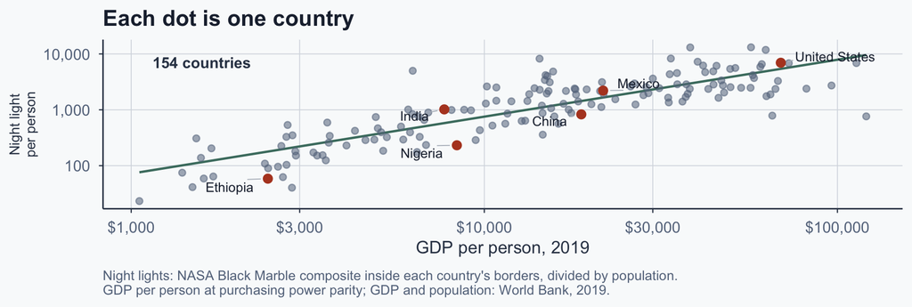

**Richer countries tend to be brighter.** The dots climb together almost in a line.

**And here is the point:** a government writes its own GDP figures. It does not write the lights.

**But careful.** This is *rich versus poor, today*. It cannot yet tell you who is exaggerating.

## A number the government cannot switch off

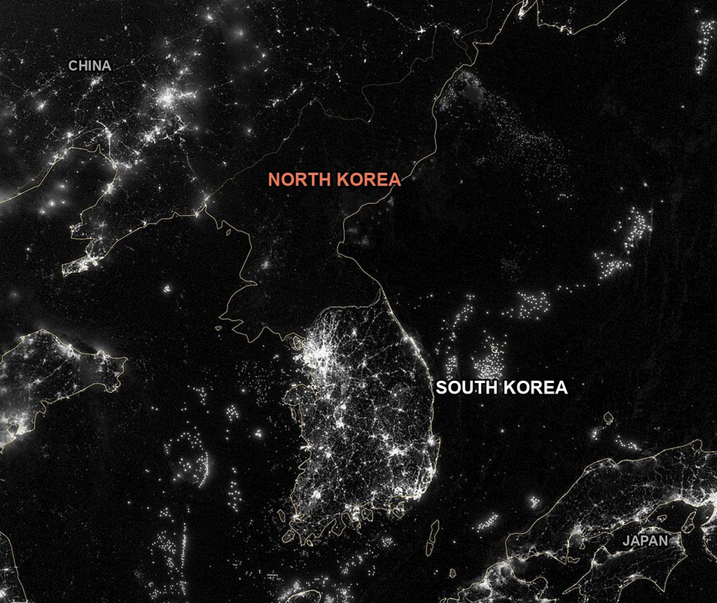

- A government reports its **own** GDP. It does not run the satellite
- So line the two up: when a country’s lights brighten, how much growth does it report that year?
- Martinez does this for **184 countries**, 1992–2013, comparing each country with itself over time
- **The test:** does the same brightening buy *more* reported growth in an autocracy than in a democracy?

Image: NASA Earth Observatory, VIIRS, 2012 — how brightly places are lit, not evidence that any government faked its figures. Lights proxy activity; they are not GDP. Source: Martinez (2022).

## The lights and the books disagree

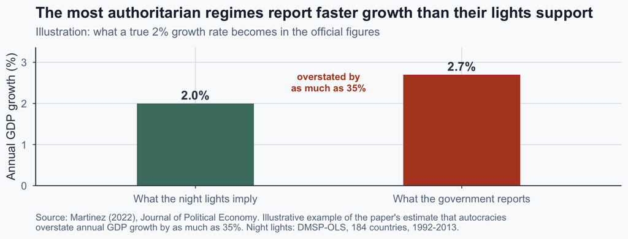

## What have we learned?

1. **Mexico — can an algorithm find the contracts?** Yes: six times better than chance at the top of the list. It was never run as a real audit, so we do not know whether corruption fell.
2. **India — what if the measured learn the measure?** The record improved far more than the fields. Of every 100 fires that left the count, about 22 really stopped.
3. **Autocracies — can outside data catch exaggeration?** Yes, in the pattern: the same light buys more reported growth under autocracy. Catching is not stopping.

**Every answer is *yes, but*.** All three produced new information. In none of them was the information, by itself, enough.

> Technology can make wrongdoing much easier to **detect**. Whether it makes wrongdoing *rarer* depends on who has the **incentive** and the **power** to act.

## References

Adam, I., & Fazekas, M. (2021). Are emerging technologies helping win the fight against corruption? A review of the state of evidence. *Information Economics and Policy*, *57*, 100950. https://doi.org/10.1016/j.infoecopol.2021.100950

Bauhr, M., Czibik, Á., de Fine Licht, J., & Fazekas, M. (2020). Lights on the shadows of public procurement: Transparency as an antidote to corruption. *Governance*, *33*(3), 495–523. https://doi.org/10.1111/gove.12432

Beraja, M., Kao, A., Yang, D. Y., & Yuchtman, N. (2023). AI-tocracy. *The Quarterly Journal of Economics*, *138*(3), 1349–1402. https://doi.org/10.1093/qje/qjad012

Dasgupta, A. (2026). *Hidden fires: Real versus measured performance in bureaucracies* [Working paper]. University of California, Merced.

## References (continued)

Fazekas, M., Tóth, I. J., & King, L. P. (2016). An objective corruption risk index using public procurement data. *European Journal on Criminal Policy and Research*, *22*(3), 369–397. https://doi.org/10.1007/s10610-016-9308-z

Klitgaard, R. (1988). *Controlling corruption*. University of California Press.

Martinez, L. R. (2022). How much should we trust the dictator’s GDP growth estimates? *Journal of Political Economy*, *130*(10), 2731–2769. https://doi.org/10.1086/720458

Medina-Hernández, M., Kertész, J., & Fazekas, M. (2026). Learning from sanctioned government suppliers: A machine learning and network science approach to detecting fraud and corruption in Mexico. *Scientific Reports*, *16*(1), 22382. https://doi.org/10.1038/s41598-026-48873-w